# Figures for large-p simulations

```r
library(REMLSimulationPaper)
```

```r
set.seed(1234)

pacman::p_load(
  tidyverse,
  MASS
)

pacman::p_load_gh(
  "dpavlyshyn/halfsibdesign" # Simulate and fit balanced half-sib designs
)

# Set a global theme for all figures in the document
theme_set(theme_bw())
```

# Figures 1 and 2: stepwise- and pairwise-REML estimates

We use the parameters described in eqs. (3, 5):

```r
p <- 50 # number of traits

I <- 100 # number of sires
J <- 3 # number of dams
K <- 5 # number of individuals per line

mu <- rep(2, p) # Just a vector of 2s - not really important for the model

sigma_a <- abs(rnorm(p))
sigma_b <- abs(rnorm(p))
sigma_e <- 1

A <- sigma_a^2 * diag(p)
B <- sigma_b^2 * diag(p)
E <- sigma_e^2 * diag(p)
```

As before, we generate our half-sib data and compute the pseudo-REML estimates, logging the eigenvalues of the corresponding estimate $\hat{\Sigma}_A$.

```r
df <- rhalfsib(mu, A, I, B, J, E, K)

A_reml_est <- stepreml_2way_df(df)
eigs_reml_est <- eigen(A_reml_est$S3, symmetric = TRUE)$values
```

## Figure 1: eigenvalue histograms

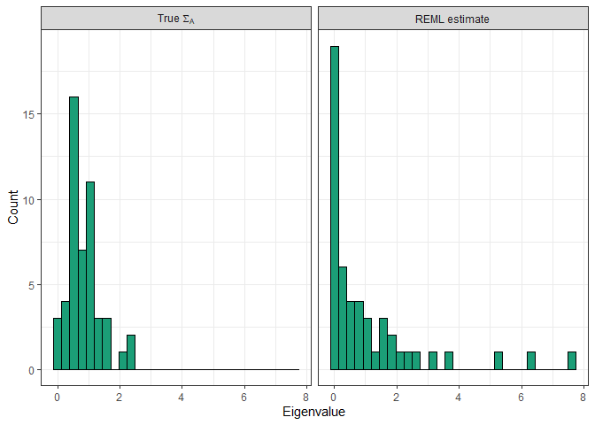

```r
estimate_names = expression(
  REML = "REML estimate",
  True = "True"~Sigma[A]
)

eig_df <- tibble(
  REML = eigs_reml_est,
  True = sigma_a
) %>%
  pivot_longer(cols = c(REML, True), names_to = "Type", values_to = "Eigenvalue") %>%
  mutate(Type = factor(Type, levels = c("True", "REML")))

ggplot(eig_df, mapping = aes(x = Eigenvalue, fill = Type)) +
  geom_histogram(
    colour = "black",
    fill = doc_colours[[1]]) +
  facet_wrap(
    ~Type,
    labeller = label_bquote(.(estimate_names[as.character(Type)]))) +
  labs(
    y = "Count"
  ) +
  theme(legend.position = "none")
```

```r
ggsave("../figs/first-REML.pdf", device = "pdf")
```

## Figure 2: Stepwise REML and Pseudo REML scatterplot

Last, we investigate the strategy of computing pairwise REML estimates for each pair of traits. We create a new estimate $\hat{\Sigma}_{A,2}$ such that the diagonal entries $[\hat{\Sigma}_{A,2}]_{ii}$ are computed by doing a single-trait analysis on trait $i$ and the off-diagonal entries $[\hat{\Sigma}_{A,2}]_{ij}$ are computed by doing a 2-trait analysis on the traits $(i,j)$.

```r
A_pairwise_est <- matrix(nrow = p, ncol = p)

for(r in 1:p) {
  # fill in diagonal
  df_sub <- filter(df, trait == r)
  A_sub_est <- stepreml_2way_df(df_sub)$S3

  A_pairwise_est[r, r] <- A_sub_est[1,1]

  if(r < q) {
    for(s in (r+1):p) {
      df_sub <- filter(df, trait %in% c(r, s))
      A_sub_est <- stepreml_2way_df(df_sub)$S3

      A_pairwise_est[r, s] <- A_sub_est[1,2]
      A_pairwise_est[s, r] <- A_pairwise_est[r, s]
    }
  }
}
```

```r
write.table(
  A_pairwise_est,
  "../data/pairwise-covariances.csv",
  sep = ",",
  row.names = FALSE,
  col.names = FALSE)
```

Plotting these eigenvalues, we see that the eigenvalues of $A_2$ are qualitatively similar to those of $A_1$.

```r
eigs_pairwise_est <- eigen(A_pairwise_est, symmetric = TRUE)$values
```

To make this comparison clearer, let $\lambda_1 > \dotsc > \lambda_q$ the the eigenvalues of $A_1$ and $\mu_1 > \dotsc > \mu_q$ be the eigenvalues of $A_2$.

In the following figure, we plot $\mu_i - \lambda_i$ against $\lambda_i$.

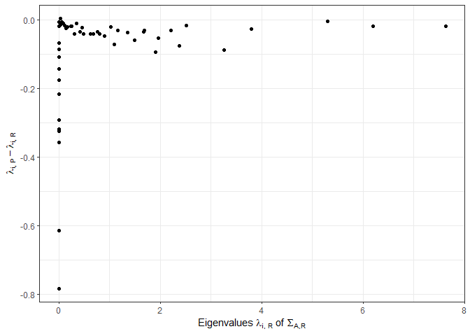

```r
ggplot(mapping = aes(x = eigs_reml_est, y = eigs_pairwise_est - eigs_reml_est)) +
  geom_point() +
  labs(
    x = expression("Eigenvalues"~lambda["i, R"]~"of"~Sigma["A,R"]),
    y = expression(lambda["i, P"] - lambda["i, R"])
  )
```

```r
ggsave("../figs/eval-diffs.pdf", device = "pdf")
```

# Figures 3 and 4: repeated samples

We set up a function to perform repeated samples

```r
repeated_sample <- function(p_vals, I, J, K, n_reps, methods, make_sigmas, make_mu, max_idx=5) {
  # output data frame
  res_df <- tibble(
    p = integer(),
    rep = integer(),
    level = character(),
    eig_idx = integer(),
    method = character(),
    pop_eig = numeric(),
    sample_eig = numeric()
  )

  for(p in p_vals) {
    A <- make_sigmas$A(p)
    B <- make_sigmas$B(p)
    E <- make_sigmas$E(p)

    mu_vec <- make_mu(p)

    for(rep in 1:n_reps) {

      df <- rhalfsib(mu_vec, A, I, B, J, E, K)

      for(method in names(methods)) {
        reml_est <- methods[[method]](df)
        #reml_est <- manova_2way_df(df)

        A_eigs <- eigen(reml_est$S3, symmetric = TRUE, only.values = TRUE)$values

        df_A <- tibble(
          p = p,
          rep = rep,
          level = "A",
          eig_idx = 1:max_idx,
          method = method,
          pop_eig = sigma_a^2,
          sample_eig = A_eigs[1:max_idx]
        )

        B_eigs <- eigen(reml_est$S2, symmetric = TRUE, only.values = TRUE)$values

        df_B <- tibble(
          p = p,
          rep = rep,
          level = "B",
          eig_idx = 1:max_idx,
          method = method,
          pop_eig = sigma_b^2,
          sample_eig = B_eigs[1:max_idx]
        )

        E_eigs <- eigen(reml_est$S1, symmetric = TRUE, only.values = TRUE)$values

        df_E <- tibble(
          p = p,
          rep = rep,
          level = "E",
          eig_idx = 1:max_idx,
          method = method,
          pop_eig = sigma_e^2,
          sample_eig = E_eigs[1:max_idx]
        )

        res_df <- bind_rows(res_df, df_A, df_B, df_E)
      }

    }
  }

  return(res_df)
}
```

## Figure 3: bias in large eigenvalues

We use the parameter values specified in eq. (6):

```r
p_vals <- seq(10, 100, by=10)
n_reps <- 50
max_idx <- 5

methods <- list(
  MANOVA = manova_2way_df,
  REML = stepreml_2way_df
)

# model parameters
sigma_a <- 1
sigma_b <- 2
sigma_e <- 1

I <- 100
J <- 3
K <- 5

mu <- 2

make_sigmas <- list(
  A = function(p) {sigma_a^2 * diag(p)},
  B = function(p) {sigma_b^2 * diag(p)},
  E = function(p) {sigma_e^2 * diag(p)}
)

make_mu <- function(p) {rep(mu, p)}

res_df <- repeated_sample(p_vals, I, J, K, n_reps, methods, make_sigmas, make_mu, max_idx=5)
```

```r
write_csv(res_df, "../data/REML-p50-eigenvalues.csv")
```

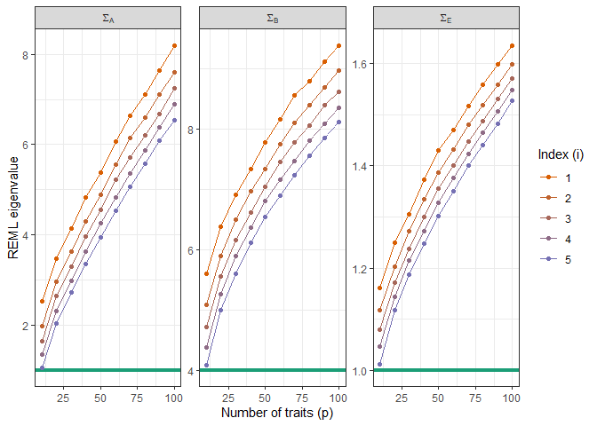

```r
cov_names = expression(
  A = Sigma[A],
  B = Sigma[B],
  E = Sigma[E]
)

summ_df <- res_df %>%
  group_by(p, level, method, eig_idx) %>%
  summarize(
    eig_mean = mean(sample_eig),
    eig_sd = sd(sample_eig),
    pop_eig = mean(pop_eig)
  )

summ_df %>%
  ggplot(aes(x = p, y = eig_mean, color = ordered(eig_idx))) +
  facet_wrap(
    ~ level,
    scales = "free_y",
    labeller = label_bquote(.(cov_names[level]))) +
  geom_line() +
  geom_hline(aes(yintercept = pop_eig), color = doc_colours[[1]], size = 1.5) +
  geom_point() +
  labs(
    x        = "Number of traits (p)",
    y        = "REML eigenvalue",
    color    = "Index (i)"
  ) +
  scale_color_manual(
    values = doc_seq_palette(length(unique(summ_df$eig_idx)))
  )
```

```r
ggsave("../figs/index.pdf", device = "pdf")
```

## Figure 4: Difference between REML and MANOVA estimates

We repeat the simulations from the previous section, but now with parameter values described in the first paragraphs of Section 4.2.

```r
# experiment parameters
p_vals <- seq(10, 70, by=10)
n_reps <- 50
max_idx <- 5

methods <- list(
  MANOVA = manova_2way_df,
  REML = stepreml_2way_df
)

# model parameters
sigma_a <- 1
sigma_b <- 2
sigma_e <- 1

I <- 100
J <- 3
K <- 5

mu <- 2

make_sigmas <- list(
  A = function(p) {sigma_a^2 * diag(rbinom(p, 1, 0.5))},
  B = function(p) {sigma_b^2 * diag(rbinom(p, 1, 0.5))},
  E = function(p) {sigma_e^2 * diag(p)}
)

make_mu <- function(p) {rep(mu, p)}

comp_df <- repeated_sample(p_vals, I, J, K, n_reps, methods, make_sigmas, make_mu, max_idx=5)
```

```r
write_csv(comp_df, "../data/REML-MANOVA-eigenvalue-comparison.csv")
```

We see that the largest eigenvalues of $\hat{\Sigma}_A$ are adjusted up slightly, whereas the largest eigenvalues of $\hat{\Sigma}_B$ are adjusted down substantially.

```r
comp_summary <- comp_df %>%
  pivot_wider(names_from = "method", values_from = "sample_eig") %>%
  mutate(est_diff = REML - MANOVA) %>%
  group_by(p, level, eig_idx) %>%
  summarize(
    diff_mean = mean(est_diff),
    diff_sd = sd(est_diff)
  )
```

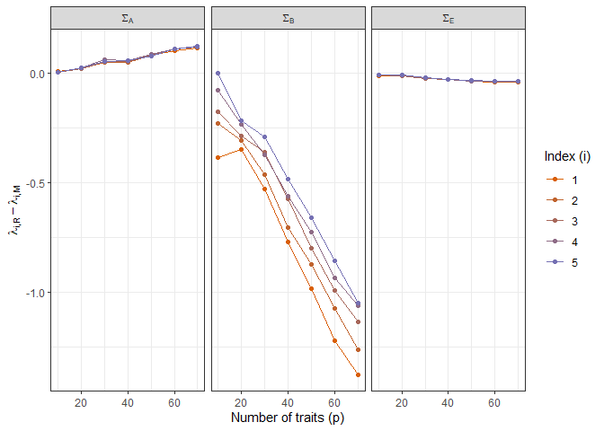

```r
comp_summary %>%
  ggplot(aes(x = p, y = diff_mean, color = ordered(eig_idx))) +
  geom_line() +
  geom_point() +
  facet_wrap(
    ~ level,
    labeller = label_bquote(.(cov_names[level]))) +
  labs(
    y = expression(lambda["i,R"] - lambda["i,M"]),
    x = "Number of traits (p)",
    color = "Index (i)"
  ) +
  scale_color_manual(
    values = doc_seq_palette(length(unique(summ_df$eig_idx)))
  )
```

```r
ggsave("../figs/e-diff.pdf", device = "pdf")
```